# Project 2

Yue Taira, Tushar Kohli, Raju Kakarlapudi

## Data

```
## # A tibble: 6 × 11
##   country           area birth_rate death_rate infant_mortality_… internet_users
##   <fct>            <dbl>      <dbl>      <dbl>              <dbl>          <dbl>
## 1 Russia        17098242       11.9      13.8                7.08       40853000
## 2 Canada         9984670       10.3       8.31               4.71       26960000
## 3 United States  9826675       13.4       8.15               6.17      245000000
## 4 China          9596960       12.2       7.44              14.8       389000000
## 5 Brazil         8514877       14.7       6.54              19.2        75982000
## 6 Australia      7741220       12.2       7.07               4.43       15810000
## # … with 5 more variables: life_exp_at_birth <dbl>,
## #   maternal_mortality_rate <int>, net_migration_rate <dbl>, population <int>,
## #   population_growth_rate <dbl>
```

```
## [1] 70.65203
```

```
## # A tibble: 177 × 12
##    country            area birth_rate death_rate infant_mortalit… internet_users
##    <fct>             <dbl>      <dbl>      <dbl>            <dbl>          <dbl>
##  1 Russia           1.71e7       11.9      13.8              7.08       40853000
##  2 Canada           9.98e6       10.3       8.31             4.71       26960000
##  3 United States    9.83e6       13.4       8.15             6.17      245000000
##  4 China            9.60e6       12.2       7.44            14.8       389000000
##  5 Brazil           8.51e6       14.7       6.54            19.2        75982000
##  6 Australia        7.74e6       12.2       7.07             4.43       15810000
##  7 India            3.29e6       19.9       7.35            43.2        61338000
##  8 Argentina        2.78e6       16.9       7.34             9.96       13694000
##  9 Kazakhstan       2.72e6       19.6       8.31            21.6         5299000
## 10 Congo, Democrat… 2.34e6       35.6      10.3             73.2          290000
## # … with 167 more rows, and 6 more variables: life_exp_at_birth <dbl>,
## #   maternal_mortality_rate <int>, net_migration_rate <dbl>, population <int>,
## #   population_growth_rate <dbl>, country_type <fct>
```

## Title and Introduction

Perhaps one the most popular international news stories over the past couple weeks has been regarding birth rates and population change in countries across the globe. In countries like Japan, population growth rate has seen a steady decline, leading some to worry the nation may soon age and disappear. In contrast, Sub-Saharan African nations are set to see a six-fold increase in population. As a group we found the trends in global population and human development to be highly interesting, leading us to the CIA Factbook. This dataset is sourced from the openintro library in R. It contains columns for the country name, country area, population, population growth rate, birth rate, death rate, life expectancy, internet users, infant mortality rate, maternal mortality rate, and net migration rate for the year 2014. The original dataset has many rows with NA values so it requires cleaning by removing those rows. In addition, a categorical variable “country type” can be made based off of the existing variable for life expectancy. This dataset is interesting because we will be able to compare and contrast different developmental trends for countries based on their statistics. In particular, we would like to look at each country’s population and birth/death rates, as well as their life expectancy and mortality rates. We expect to see higher life expectancy and lower mortality rates in more developed countries, and the opposite for less developed countries. As for birth and death rates, we expect to see lower rates for more developed countries, and higher ones for less developed countries.

## Exploratory Data Analysis

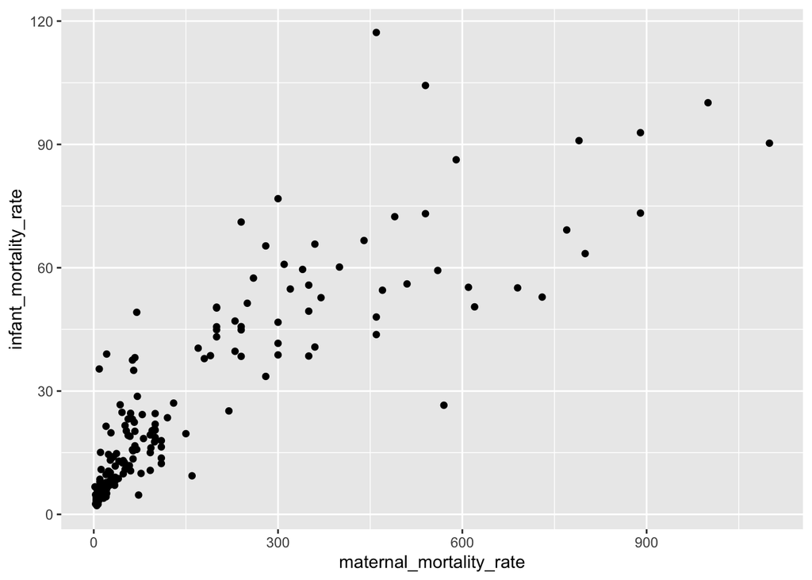

```r
# create scatter plot for maternal mortality rate and infant mortality rate
ggplot(cia_clean, aes(x = maternal_mortality_rate, y = infant_mortality_rate)) +
  geom_point()
```

```r
# find correlation between infant and maternal mortality rates
cor(cia_clean$maternal_mortality_rate,cia_clean$infant_mortality_rate, use = "pairwise.complete.obs")
```

```
## [1] 0.857046
```

```r
# create dataframe from cia_clean with only numeric variables
cia_num <- cia_clean %>%
  select_if(is.numeric)

# build a correlation matrix between all numeric variables
cor(cia_num, use = "pairwise.complete.obs")
```

```
##                                area  birth_rate   death_rate
## area                     1.00000000 -0.09300600  0.074589447
## birth_rate              -0.09300600  1.00000000  0.109784153
## death_rate               0.07458945  0.10978415  1.000000000
## infant_mortality_rate   -0.06061531  0.86536598  0.322897930
## internet_users           0.56992897 -0.19440771 -0.005720992
## life_exp_at_birth        0.04728153 -0.82766058 -0.474209922
## maternal_mortality_rate -0.04838870  0.79056586  0.383781491
## net_migration_rate       0.04219178 -0.11099481 -0.071592852
## population               0.45346935 -0.06904815 -0.030836269
## population_growth_rate  -0.04338162  0.54618294 -0.197333986
##                         infant_mortality_rate internet_users life_exp_at_birth
## area                             -0.060615312    0.569928967        0.04728153
## birth_rate                        0.865365979   -0.194407707       -0.82766058
## death_rate                        0.322897930   -0.005720992       -0.47420992
## infant_mortality_rate             1.000000000   -0.155193196       -0.88750000
## internet_users                   -0.155193196    1.000000000        0.18115597
## life_exp_at_birth                -0.887499996    0.181155970        1.00000000
## maternal_mortality_rate           0.857046028   -0.141888829       -0.82081171
## net_migration_rate               -0.102949745    0.022248502        0.13368824
## population                        0.001136847    0.760296108        0.03127375
## population_growth_rate            0.418880039   -0.109103614       -0.33713188
##                         maternal_mortality_rate net_migration_rate   population
## area                                -0.04838870        0.042191778  0.453469351
## birth_rate                           0.79056586       -0.110994813 -0.069048150
## death_rate                           0.38378149       -0.071592852 -0.030836269
## infant_mortality_rate                0.85704603       -0.102949745  0.001136847
## internet_users                      -0.14188883        0.022248502  0.760296108
## life_exp_at_birth                   -0.82081171        0.133688242  0.031273746
## maternal_mortality_rate              1.00000000       -0.069349092 -0.033936150
## net_migration_rate                  -0.06934909        1.000000000  0.005274375
## population                          -0.03393615        0.005274375  1.000000000
## population_growth_rate               0.38368855        0.745155206 -0.034746764
##                         population_growth_rate
## area                               -0.04338162
## birth_rate                          0.54618294
## death_rate                         -0.19733399
## infant_mortality_rate               0.41888004
## internet_users                     -0.10910361
## life_exp_at_birth                  -0.33713188
## maternal_mortality_rate             0.38368855
## net_migration_rate                  0.74515521
## population                         -0.03474676
## population_growth_rate              1.00000000
```